# Sampling, Sample Size Calculation and Sampling Distributions

Hector Mathonsi

13 October 2024

# 1 Bootstrap Sampling

## 1.1 Scenario

Waste generation around the world is growing exponentially. Historically, the proportion of South African households who recycle is very low since the country does not have a structured recycling system. Despite this there is more public awareness of the need to recycle to create a healthier planet. A market researcher wants to estimate the proportion of households in Gauteng that recycle paper, plastic, glass and aluminium cans. The recycle.csv dataset contains the results from a random sample of n = 40 households, and includes the variables: HHold, Convenience, Recycle. The variable details are given in the following:

- **HHold**: Household number
- **Convenience**: Convenience rating (Scale of 1 to 5, 1 being very inconvenient and 5 being very convenient)
- **Recycle**: Recycling status (1 for Yes, 0 for No)

## 1.2 Data

The `recycle.csv` data file contains the sample data for 40 households in Gauteng.

```r
recycle_data <- read.csv("../data/recycle.csv")    # Load the recycle data
recycle_data
```

| Hhold | Convenience | Recycle |
| --- | --- | --- |
| 1 | 3 | 0 |
| 2 | 11 | 0 |
| 3 | 2 | 1 |
| 4 | 2 | 0 |
| 5 | 3 | 0 |
| 6 | 1 | 0 |
| 7 | 2 | 0 |
| 8 | 3 | 0 |
| 9 | 1 | 1 |
| 10 | 2 | 0 |

[output cut: 30 more lines]

```r
summary(recycle_data)    # Summary of the recycle data
```

```
     Hhold        Convenience       Recycle
 Min.   : 1.00   Min.   : 1.00   Min.   : 0.000
 1st Qu.:10.75   1st Qu.: 1.00   1st Qu.: 0.000
 Median :20.50   Median : 2.00   Median : 0.000
 Mean   :20.50   Mean   : 2.55   Mean   : 0.625
 3rd Qu.:30.25   3rd Qu.: 3.00   3rd Qu.: 1.000
 Max.   :40.00   Max.   :11.00   Max.   :10.000
```

```r
str(recycle_data)        # Structure of the recycle data
```

```
'data.frame':   40 obs. of  3 variables:
 $ Hhold      : int  1 2 3 4 5 6 7 8 9 10 ...
 $ Convenience: int  3 11 2 2 3 1 2 3 1 2 ...
 $ Recycle    : int  0 0 1 0 0 0 0 0 1 0 ...
```

## 1.3 Cleaning Data

Evaluate the quality of the data using frequency tables to identify any potential data errors/inconsistencies.

```r
table(recycle_data$Convenience)    # Frequency table for Convenience
```

```
 1  2  3  4  5  6 11
11 14  8  3  2  1  1
```

```r
which(recycle_data$Convenience < 1 | recycle_data$Convenience > 5)    # Check for invalid values
```

```
[1]  2 24
```

```r
# Remove invalid values
new_recycle <- recycle_data
new_recycle[new_recycle$Convenience==11,] <- 1
new_recycle
```

| Hhold | Convenience | Recycle |
| --- | --- | --- |
| 1 | 3 | 0 |
| 1 | 1 | 1 |
| 3 | 2 | 1 |
| 4 | 2 | 0 |
| 5 | 3 | 0 |
| 6 | 1 | 0 |
| 7 | 2 | 0 |
| 8 | 3 | 0 |
| 9 | 1 | 1 |
| 10 | 2 | 0 |

[output cut: 30 more lines]

```r
table(recycle_data$Recycle)    # Frequency table for Recycle
```

```
 0  1  2 10
25 13  1  1
```

```r
which(recycle_data$Recycle < 0 | recycle_data$Recycle > 1)    # Check for invalid values
```

```
[1] 24 37
```

```r
# Remove invalid values
new_recycle <- new_recycle[-c(24,37),]
new_recycle
```

|  | Hhold | Convenience | Recycle |
| --- | --- | --- | --- |
| 1 | 1 | 3 | 0 |
| 2 | 1 | 1 | 1 |
| 3 | 3 | 2 | 1 |
| 4 | 4 | 2 | 0 |
| 5 | 5 | 3 | 0 |
| 6 | 6 | 1 | 0 |
| 7 | 7 | 2 | 0 |
| 8 | 8 | 3 | 0 |
| 9 | 9 | 1 | 1 |
| 10 | 10 | 2 | 0 |

[output cut: 28 more lines]

```r
dim(new_recycle)    # Check the dimensions of the cleaned data
```

```
[1] 38  3
```

## 1.4 Bootstrap Sampling

The researcher feels that estimates from bootstrap samples will be more accurate that a single point estimate from the sample. Use your cleaned dataset to perform the following bootstrap analysis:

- Draw 40 bootstrap samples of size n = 40 selected from your cleaned data of variable Recycle.
- Create a histogram of the results of the 40 bootstrap samples.
- Find the point estimate of variable Recycle from the cleaned dataset, and the bootstrap estimate from your bootstrap samples.

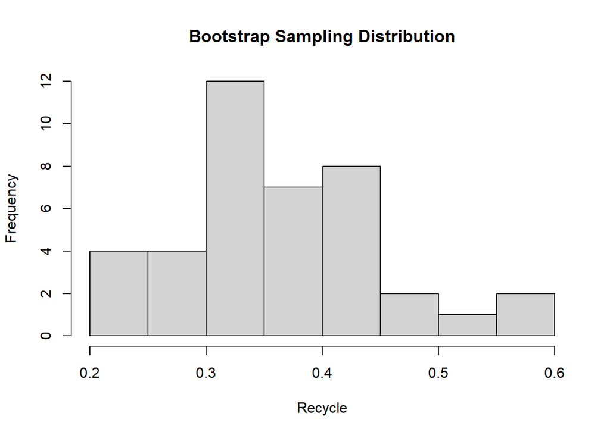

```r
# Bootstrap Sampling
recycle_prop <- numeric(0)

for (i in 1:40) {
  bootstrap_sample <- sample(new_recycle$Recycle, 40, replace = TRUE)
  recycle_prop <- rbind(recycle_prop, mean(bootstrap_sample))
}

# Create a histogram of the results of the 40 bootstrap samples
hist(recycle_prop, main = "Bootstrap Sampling Distribution", xlab = "Recycle", ylab = "Frequency")
```

```r
# Point estimate of variable Recycle from the cleaned dataset
point_estimate <- mean(new_recycle$Recycle)
point_estimate
```

```
[1] 0.3684211
```

```r
# Bootstrap estimate from the bootstrap samples
bootstrap_estimate <- mean(recycle_prop)
bootstrap_estimate
```

```
[1] 0.37625
```

# 2 Systematic Sampling

## 2.2 Data

```r
seedlings <- read.csv("../data/seedlings.csv")    # Load the spring onions data
seedlings
```

| Plot | Xcoord | Ycoord | Seedlings |
| --- | --- | --- | --- |
| 1 | 1 | 10 | 8 |
| 2 | 2 | 10 | 20 |
| 3 | 3 | 10 | 16 |
| 4 | 4 | 10 | 14 |
| 5 | 5 | 10 | 11 |
| 6 | 6 | 10 | 24 |
| 7 | 7 | 10 | 18 |
| 8 | 8 | 10 | 16 |
| 9 | 9 | 10 | 26 |
| 10 | 10 | 10 | 10 |

[output cut: 190 more lines]

## 2.3 Systematic Sampling

Use systematic sampling to select a sample of size n = 33 from the list of 200 plots (round down k to the nearest integer). Create a scatter plot of the centroids of all 200 plots. Add the 33 plots from your sample to this plot, and show those in a different colour, marker type and size. Provide your R code and the graph in the answer sheet. Hint: use Help to get more information on the plot parameters, by typing par in the search box.

```r
k <- floor(200/33)

sample_list <- sample(k, 1)

for (i in 2:33) {
  sample_list[i] <- sample_list[i-1] + k
}

sys_sample <- seedlings[sample_list, ]
sys_sample
```

|  | Plot | Xcoord | Ycoord | Seedlings |
| --- | --- | --- | --- | --- |
| 4 | 4 | 4 | 10 | 14 |
| 10 | 10 | 10 | 10 | 10 |
| 16 | 16 | 16 | 10 | 19 |
| 22 | 22 | 2 | 9 | 19 |
| 28 | 28 | 8 | 9 | 10 |
| 34 | 34 | 14 | 9 | 9 |
| 40 | 40 | 20 | 9 | 23 |
| 46 | 46 | 6 | 8 | 19 |
| 52 | 52 | 12 | 8 | 16 |
| 58 | 58 | 18 | 8 | 20 |

[output cut: 23 more lines]

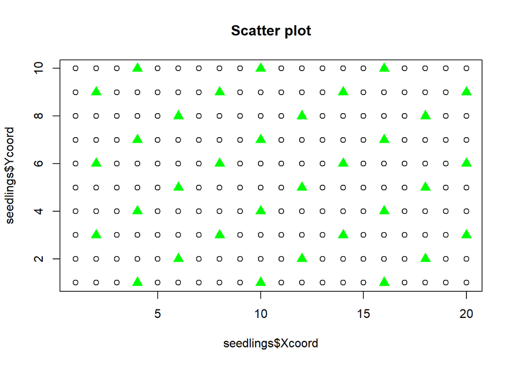

```r
# Scatter plot
plot(x = seedlings$Xcoord, y = seedlings$Ycoord, main = "Scatter plot")
points(sys_sample$Xcoord, sys_sample$Ycoord, pch = 17, col = "green", cex = 1.5)
```

```r
# Estimate total number of spring onions plants in the whole field
mean_seedlings <- mean(seedlings$Seedlings)
total_seedlings <- 200 * mean(seedlings$Seedlings)
mean_seedlings
```

```
[1] 15.525
```

```r
total_seedlings
```

```
[1] 3105
```

# 3 Cluster Sampling

A biologist wants to estimate the average volume of eggs of a certain species of bird. This species is known to nest in a certain area on the west coast of South Africa. Currently, there are 39 nests, and the collection of eggs in a nest is called a clutch. The number of eggs in a clutch varies between 6 and 13. The biologist believes that the variability of eggs sizes within clutches is the same across all clutches. He decides to use cluster sampling to select a random sample of 5 clutches (nests), and then use simple random sampling to select 6 eggs from each clutch, giving a total of n = 30 eggs. The eggs.csv dataset consists of the following variables for the whole population of eggs:

- **CLUTCH**: Clutch number 1 to 39
- **VOLUME**: Egg volume, calculated as 0.000507 × LENGTH × BREADTH2

## 3.1 Data

The `eggs.csv` data file contains the clutch numbers and egg volumes for the 39 nests.

```r
eggs <- read.csv("../data/eggs.csv")    # Load the eggs data
eggs
```

| CLUTCH | VOLUME |
| --- | --- |
| 1 | 2.4259950 |
| 1 | 2.4336000 |
| 1 | 1.7018165 |
| 1 | 2.3474100 |
| 1 | 2.2318140 |
| 1 | 1.9671093 |
| 1 | 2.0307631 |
| 1 | 1.9814827 |
| 1 | 2.0500646 |
| 2 | 2.0981130 |

[output cut: 358 more lines]

```r
summary(eggs)    # Summary of the eggs data
```

```
     CLUTCH         VOLUME
 Min.   : 1.0   Min.   :0.573
 1st Qu.:11.0   1st Qu.:1.680
 Median :21.0   Median :2.394
 Mean   :20.3   Mean   :2.333
 3rd Qu.:30.0   3rd Qu.:2.945
 Max.   :39.0   Max.   :4.481
```

```r
str(eggs)        # Structure of the eggs data
```

```
'data.frame':   368 obs. of  2 variables:
 $ CLUTCH: int  1 1 1 1 1 1 1 1 1 2 ...
 $ VOLUME: num  2.43 2.43 1.7 2.35 2.23 ...
```

## 3.2 Cluster Sampling

Use cluster sampling to select a cluster sample from the eggs.csv dataset. List the 5 clutch numbers (clusters) you have selected. Estimate the average egg volume from your data.

```r
random_clutch <- sample(eggs$CLUTCH, 5, replace = FALSE)
random_clutch
```

```
[1]  2 22 10 32 33
```

```r
clutch_dataframe <- data.frame()

for (i in random_clutch) {
  sample_eggs <- eggs[eggs$CLUTCH == i, ]
  srs_eggs <- sample_eggs[sort(sample(nrow(sample_eggs), 6)), ]
  clutch_dataframe <- rbind(clutch_dataframe, srs_eggs)
}

clutch_dataframe
```

|  | CLUTCH | VOLUME |
| --- | --- | --- |
| 11 | 2 | 2.4427260 |
| 12 | 2 | 2.3955750 |
| 13 | 2 | 2.5192830 |
| 15 | 2 | 2.5197900 |
| 16 | 2 | 2.5020450 |
| 19 | 2 | 1.9354877 |
| 194 | 22 | 2.6069940 |
| 201 | 22 | 3.5292067 |
| 202 | 22 | 2.8495682 |
| 203 | 22 | 3.0722578 |

[output cut: 20 more lines]

```r
# Estimate the average egg volume
mean(clutch_dataframe$VOLUME)
```

```
[1] 2.34558
```